# Tutorial 4: Regression

*Athena Liu, March 2019*

**Important note: The code in this lecture note is written in Python - You are NOT required to understand any of them. Instead, focus on the process of data analysis. I have provided the information on how to do regression in MATLAB below each section.**

Three Types of Regression:

- Linear Regression
- Polynomial Regression
- Multivariable Regression

## General Idea (Works for all 3 types of regression!)

You have a variable $y$ that is dependent on $m$ variables $[x_1, x_2, ... ,x_m]$

You want to find out the relation between $y$ and $[x_1, x_2, ... ,x_m]$, i. e.

$$ y = \mathbf{\beta}\cdot{\mathbf{x}} = \beta_0\cdot1 + \beta_1x_1 + \beta_2x_2 + ... + \beta_mx_m$$

where $\mathbf{x} = [1, x_1, x_2, ... ,x_m]^T$,

and $\mathbf{\beta} = [\beta_0, \beta_1, \beta_2, ... ,\beta_m]$.

**You want to find out $\beta~$! And that has to be found through the data!**

You collect $n$ sets of data ($n$ measurements), and have a table that looks like this:

| Data Set No. | y | x_1 | x_2 | ... | x_m |
| --- | --- | --- | --- | --- | --- |
| 1 | $y^{(1)}$ | $x^{(1)}_1$ | $x^{(1)}_2$ | ... | $x^{(1)}_m$ |
| 2 | $y^{(2)}$ | $x^{(2)}_1$ | $x^{(2)}_2$ | ... | $x^{(2)}_m$ |
| ... |  |  |  |  |  |
| n | $y^{(n)}$ | $x^{(n)}_1$ | $x^{(n)}_2$ | ... | $x^{(n)}_m$ |

So now you want to have:

$$\left[ {\begin{array}{*{20}{c}} {{y^{(1)}}}\\ {{y^{(2)}}}\\ {...}\\ {{y^{(n)}}} \end{array}} \right] \approx \left[ {\begin{array}{*{20}{c}} {{\beta _0} \cdot 1 + {\beta _1}{x^{(1)}}_1 + {\beta _2}{x^{(1)}}_2 + ... + {\beta _m}{x^{(1)}}_m}\\ {{\beta _0} \cdot 1 + {\beta _1}{x^{(2)}}_1 + {\beta _2}{x^{(2)}}_2 + ... + {\beta _m}{x^{(2)}}_m}\\ {...}\\ {{\beta _0} \cdot 1 + {\beta _1}{x^{(n)}}_1 + {\beta _2}{x^{(n)}}_2 + ... + {\beta _m}{x^{(n)}}_m} \end{array}} \right] $$

You can rewrite the above in a nice matrix form:

$$\left[ {\begin{array}{*{20}{c}} {{y^{(1)}}}\\ {{y^{(2)}}}\\ {...}\\ {{y^{(n)}}} \end{array}} \right] \approx \left[ {\begin{array}{*{20}{c}} {{1}}&{{x^{(1)}}_1}&{{x^{(1)}}_2}&{...}&{{x^{(1)}}_m}\\ {1}&{{x^{(2)}}_1}&{{x^{(2)}}_2}&{...}&{{x^{(2)}}_m}\\ {1}&{...}&{}&{}&{}\\ {1}&{{x^{(n)}}_1}&{{x^{(n)}}_2}&{...}&{{x^{(n)}}_m} \end{array}} \right] \cdot \left[ {\begin{array}{*{20}{c}} {{\beta _0}}\\ {{\beta _1}}\\ {{\beta _2}}\\ {...}\\ {{\beta _m}} \end{array}} \right] $$

Let's just call it

$$\mathbf{y} \approx \mathbf{G} \cdot \mathbf{\beta}$$

Well, you cannot solve it directly, so here comes the

## Least-Squares Estimation

The lease-squares estimation gives you that the best fit occurs when

$$ \mathbf{G}^T\mathbf{y} = \mathbf{G}^T\mathbf{G} \cdot \mathbf{\beta} $$

Then you just solve this equation system to get $\beta$:

$$ \mathbf{\beta} = ( \mathbf{G}^T \mathbf{G} )^{-1} \cdot \mathbf{G}^T \mathbf{y} $$

## 1. Linear Regression (Single Regression)

**We don't have a tutorial question for this, but you will likely see a question in your exams!**

Now your variable $y$ only depends on $1$ variable $x_1$

You want to find out the relation between $y$ and $x_1$, i. e.

$$ y = \mathbf{\beta}\cdot{\mathbf{x}} = \beta_0\cdot1 + \beta_1x_1$$

where $\mathbf{x} = [1, x_1]$,

and $\mathbf{\beta} = [\beta_0, \beta_1]$.

So now you want to have:

$$\left[ {\begin{array}{*{20}{c}} {{y^{(1)}}}\\ {{y^{(2)}}}\\ {...}\\ {{y^{(n)}}} \end{array}} \right] \approx \left[ {\begin{array}{*{20}{c}} {{\beta _0} \cdot 1 + {\beta _1}{x^{(1)}}_1 }\\ {{\beta _0} \cdot 1 + {\beta _1}{x^{(2)}}_1 }\\ {...}\\ {{\beta _0} \cdot 1 + {\beta _1}{x^{(n)}}_1 } \end{array}} \right] $$

You can rewrite the above in a nice matrix form:

$$\left[ {\begin{array}{*{20}{c}} {{y^{(1)}}}\\ {{y^{(2)}}}\\ {...}\\ {{y^{(n)}}} \end{array}} \right] \approx \left[ {\begin{array}{*{20}{c}} {{1}}&{{x^{(1)}}_1}\\ {1}&{{x^{(2)}}_1}\\ {...}&{}\\ {1}&{{x^{(n)}}_1} \end{array}} \right] \cdot \left[ {\begin{array}{*{20}{c}} {{\beta _0}}\\ {{\beta _1}} \end{array}} \right] $$

Let's just call it

$$\mathbf{y} \approx \mathbf{G} \cdot \mathbf{\beta}$$

You got the $\mathbf{G}$ matrix for linear regression, and you know how to do the rest!

### Examples

- Temperature v.s. Number of icecreams sold
- Stress v.s. Strain

```
y_fit = -0.03 + 1.07*x
R_Square = 0.9882
```

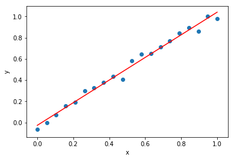

```python
import matplotlib as plt
import numpy as np
from pylab import *

x = np.linspace(0,1,20)
y = x + np.random.normal(0, 0.05, 20)

from scipy import stats
b1, b0, r_value, p_value, std_err = stats.linregress(x,y)
y_fit = b0 + b1 * x
print(f'y_fit = {round(b0,2)} + {round(b1,2)}*x')
print(f'R_Square = {round(r_value**2,4)}')

plt.scatter(x, y)
plt.plot(x, y_fit, c='r')
plt.xlabel('x')
plt.ylabel('y')
plt.show()
```

**Linear regression is super easy to do in MATLAB, basically just** :

```
X = [ones(length(x),1) x];
b = X\y
```

Check the example in https://www.mathworks.com/help/matlab/data_analysis/linear-regression.html to learn more!

## 2. Polynomial Regression (Tutorial Question 1)

What if the variable $y$ only depends on one variable $x$, but the relationship is clearly not linear?

Let's look at the plot:

```
[-3.0, -1.0, 1.0, 3.0]
```

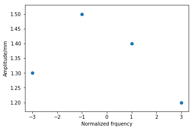

```python
frequency = [33.2, 33.4, 33.6, 33.8]
fmean = np.mean(frequency)
# Normalize frequency
x = [round((fi-fmean)/(0.5*0.2)) for fi in frequency]
amp = [1.3, 1.5, 1.4, 1.2]
print(x)
plt.scatter(x, amp)
plt.xlabel('Normalized frquency')
plt.ylabel('Amplitude/mm')
plt.show()
```

You want to fit in a parabola:

$$ y = \mathbf{\beta}\cdot{\mathbf{x}} = \beta_0\cdot1 + \beta_1x + \beta_2 x^2$$

Well doesn't that look familiar?

Just choose $\mathbf{x} = [1, x, x^2]$, and $\mathbf{\beta} = [\beta_0, \beta_1, \beta_2]$, and you have the familiar form again:

$$ y = \mathbf{\beta}\cdot{\mathbf{x}}$$

So now you just need to change your $\mathbf{G}$ matrix to:

$$\mathbf{G} = \left[ {\begin{array}{*{20}{c}} {{1}}&{{x^{(1)}}} &{{x^{(1)}}^2}\\ {1}&{{x^{(2)}}} &{{x^{(2)}}^2}\\ {...}&{} & {}\\ {1}&{{x^{(n)}}}&{{x^{(n)}}^2} \end{array}} \right] $$

You just need to solve for the $\beta$ coefficients through the least-squares estimations!

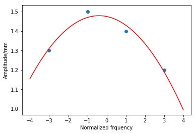

```
b0, b1, b2 =  [-0.025 -0.02   1.475]
Peak value happens at x0 =  -0.4
```

```python
coef = np.polyfit(x, amp, 2)

parabola = np.poly1d(coef)
xp = np.linspace(-4, 4, 100)
fitapm = parabola(xp)

plt.plot(xp, fitapm, c='r')

plt.scatter(x, amp)
plt.xlabel('Normalized frquency')
plt.ylabel('Amplitude/mm')
plt.show()

print('b0, b1, b2 = ',coef)
print("Peak value happens at x0 = ", round(-coef[1]/coef[0]/2,2))
```

**To do a polynomial fit in MATLAB, go check this link:**

https://www.mathworks.com/help/matlab/ref/polyfit.html

## 3. Multivariate Regression (Question 2)

Predict $MOR$ (Modulus of Rupture) using the other variables!

Let's read in the data first:

```python
import pandas as pd
data = pd.read_csv("DK.csv")
data.head()
```

|  | # | MOR | UCS | MOEj | CLTa | CLTm | Dens |
| --- | --- | --- | --- | --- | --- | --- | --- |
| 0 | 3 | 3.80 | 5.71 | 1.17 | 1.17 | 0.81 | 0.478 |
| 1 | 5 | 5.26 | 4.98 | 1.24 | 1.19 | 0.82 | 0.443 |
| 2 | 7 | 5.39 | 3.71 | 1.47 | 1.48 | 0.88 | 0.585 |
| 3 | 9 | 13.28 | 7.64 | 2.01 | 1.69 | 1.30 | 0.530 |
| 4 | 11 | 4.60 | 3.98 | 0.96 | 1.07 | 0.75 | 0.470 |

We want to predice MOR using one or more among MOEj, CLTa, CLTm, and Dens.

You are required to do at least 1 single regression and 1 multivariate regression

### Single Regression

For example, let's just look at MOR v.s. MOEj:

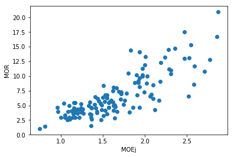

```python
import matplotlib
%matplotlib inline

MOR = data['MOR']
MOEj = data['MOEj']

scatter(MOEj, MOR)
xlabel('MOEj')
ylabel('MOR')
show()
```

This looks like a linear relationship! Let's try to do that:

```
y_fit = -4.23 + 6.58*x
R_Square = 0.6739
```

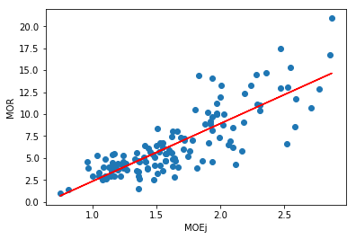

```python
from scipy import stats
b1, b0, r_value, p_value, std_err = stats.linregress(MOEj, MOR)
MOR_fit = b0 + b1 * MOEj
print(f'y_fit = {round(b0,2)} + {round(b1,2)}*x')
print(f'R_Square = {round(r_value**2,4)}')

scatter(MOEj, MOR)
xlabel('MOEj')
ylabel('MOR')
plot(MOEj, MOR_fit, c='r')

show()
```

### 2. Multivariate Regression (Multiple Regression)

Can we improve our regression using two or more variables to predict MOR?

Let's try predicting MOR using MOEj and CLTa!

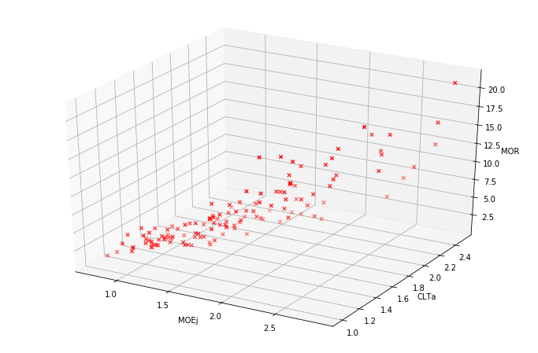

```python
from mpl_toolkits.mplot3d import Axes3D # This import registers the 3D projection, but is otherwise unused.
import matplotlib.pyplot as plt

CLTa = data['CLTa']

fig = plt.figure(figsize=(12, 8))
ax = fig.add_subplot(111, projection='3d')
ax.scatter(MOEj, CLTa, MOR, c='r', marker='x')

ax.set_xlabel('MOEj')
ax.set_ylabel('CLTa')
ax.set_zlabel('MOR')

plt.show()
```

```python
import statsmodels.api as sm

X = data[['MOEj', 'CLTa']]
Y = MOR

X = sm.add_constant(X) # adding a constant so that X = [1 MOEj CLTa]

model = sm.OLS(Y, X).fit()
print(model.summary())
```

```
                            OLS Regression Results
==============================================================================
Dep. Variable:                    MOR   R-squared:                       0.692
Model:                            OLS   Adj. R-squared:                  0.688
Method:                 Least Squares   F-statistic:                     144.1
Date:                Sat, 09 Mar 2019   Prob (F-statistic):           1.68e-33
Time:                        00:04:42   Log-Likelihood:                -280.65
No. Observations:                 131   AIC:                             567.3
Df Residuals:                     128   BIC:                             575.9
Df Model:                           2
Covariance Type:            nonrobust
==============================================================================
                 coef    std err          t      P>|t|      [0.025      0.975]
------------------------------------------------------------------------------
const         -2.5399      0.909     -2.793      0.006      -4.339      -0.740
MOEj           9.3133      1.059      8.797      0.000       7.218      11.408
CLTa          -4.1375      1.487     -2.783      0.006      -7.080      -1.195
==============================================================================
Omnibus:                        9.559   Durbin-Watson:                   1.936
Prob(Omnibus):                  0.008   Jarque-Bera (JB):               11.938
Skew:                           0.439   Prob(JB):                      0.00256
Kurtosis:                       4.190   Cond. No.                         25.9
==============================================================================

Warnings:
[1] Standard Errors assume that the covariance matrix of the errors is correctly specified.
```

Great, the R-squared is $0.692$, closer to $1$ than our previous linear fit!

This two-variable regression gives:

$$ MOR = -2.5399 + 9.3133MOEj - 4.1375 CLTa$$

Let's plot the fitted surface to see how well it works!

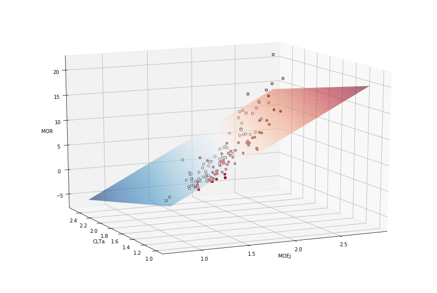

```python
## Create the fitted plane

xx1, xx2 = np.meshgrid(np.linspace(X.MOEj.min(), X.MOEj.max(), 100),
np.linspace(X.CLTa.min(), X.CLTa.max(), 100))
# plot the hyperplane by evaluating the parameters on the grid
Z = model.params[0] + model.params[1] * xx1 + model.params[2] * xx2

# create matplotlib 3d axes
fig = plt.figure(figsize=(12, 8))
ax = Axes3D(fig, azim=-115, elev=15)

# plot hyperplane
surf = ax.plot_surface(xx1, xx2, Z, cmap=plt.cm.RdBu_r, alpha=0.6, linewidth=0)

# plot data points - points over the HP are white, points below are black
resid = Y - model.predict(X)
ax.scatter(MOEj, CLTa, MOR, c='r', marker='x')
ax.scatter(X[resid >= 0].MOEj, X[resid >= 0].CLTa, Y[resid >= 0], color='black', alpha=1.0, facecolor='white')
ax.scatter(X[resid < 0].MOEj, X[resid < 0].CLTa, Y[resid < 0], color='black', alpha=1.0)

# set axis labels
ax.set_xlabel('MOEj')
ax.set_ylabel('CLTa')
ax.set_zlabel('MOR')
plt.show()
```

Now it's your turn to explore using more variables or different variables to predict MOR.

See if you can furthur improve the prediction!

**To do multivariate regression in MATLAB, check this page:**

https://www.mathworks.com/help/stats/regress.html